# DSDA 1995

Data Science and Society using R

Lecture 9 | Exploring Data

## Plan for Today

- Examining how to explore data in R

## Exploratory Data Analysis

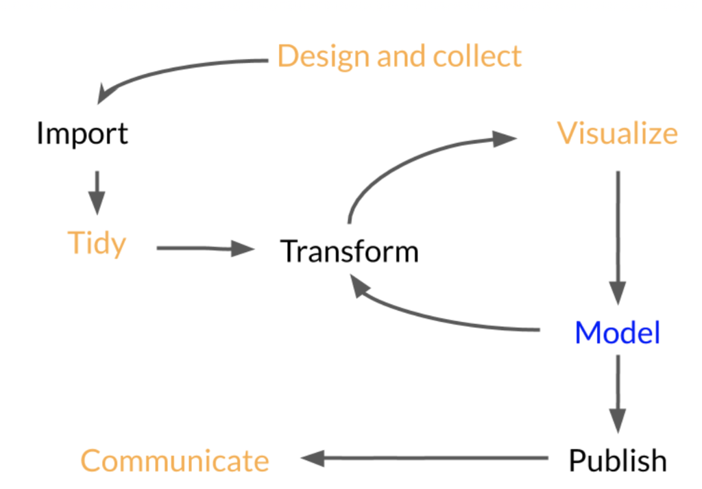

## Exploratory Data Analysis

- Data exploration is a process:
- Design and collect
  - What are you interested in?
  - Data collection process
- Import the data
- Tidy the data (more to come later)
- Transform the data
- Visualize the data
- Model the data

## Questions to Consider

- What type of variation occurs within my variables?
  - the tendency of the values of a variable to change from measurement to measurement
- What type of covariation occurs between my variables?
  - the tendency for the values of two or more variables to vary together in a related way

## Useful Terms

- **Variable**
  - quantity, quality, or property that you can measure
- **Value**
  - The state of a variable when you measure it
  - The value of a variable may change from measurement to measurement
- **Observation**
  - A set of measurements made under similar conditions (you usually make all of the measurements in an observation at the same time and on the same object)
  - Will contain several values, each associated with a different variable
  - Sometimes refer to an observation as a data point
- **Tabular Data**
  - Is a set of values, each associated with a variable and an observation
  - Tabular data is `tidy` if each value is placed in its own “cell”, each variable in its own column, and each observation in its own row

## Variation

- Variation
  - the tendency of the values of a variable to change from measurement to measurement
    - Think about eye color
- Every variable has its own pattern of variation, which can reveal interesting information
- The best way to understand that pattern is to visualize the distribution of the variable’s values

## Visualizing Distributions

- How you visualize the distribution of a variable will depend on whether the variable is categorical or continuous
- Categorical Variables
  - only take one of a small set of values
  - R will usually save these as factor or character vectors

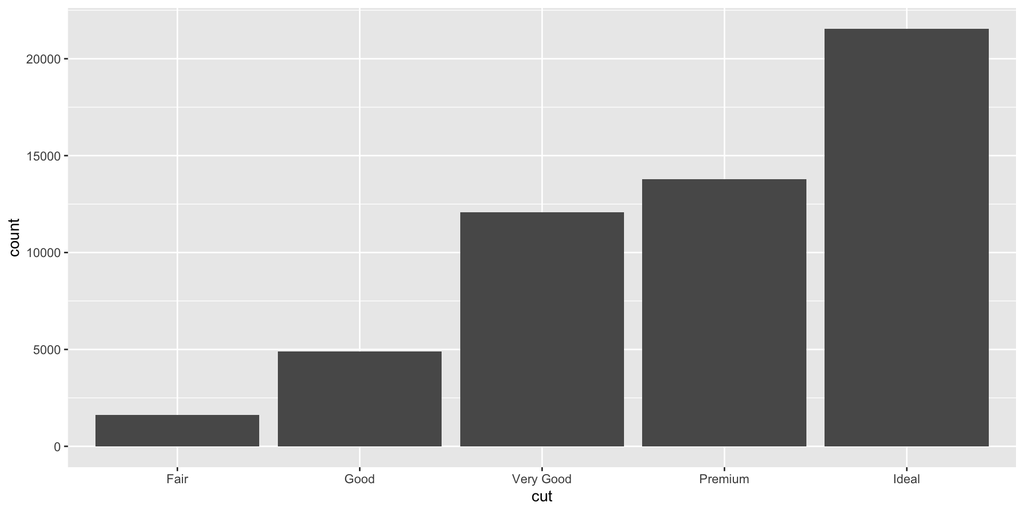

```r
ggplot(data = diamonds) +
  geom_bar(mapping = aes(x = cut))
```

## Visualizing Distributions

- Continuous
  - can take any of an infinite set of ordered values

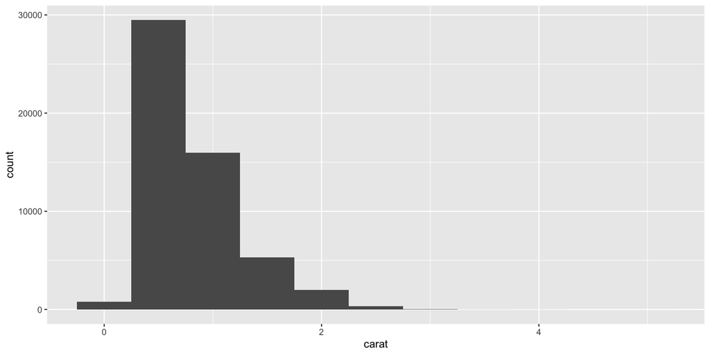

```r
ggplot(data = diamonds) +
  geom_histogram(mapping = aes(x = carat), binwidth = 0.5)
```

## Visualizing Distributions

- Histogram
  - Divides the x-axis into equally spaced bins
  - Uses the height of a bar to display the number of observations that fall in each bin
- You can set the width of the intervals in a histogram with the `binwidth` argument
  - Measured in the units of the x variable

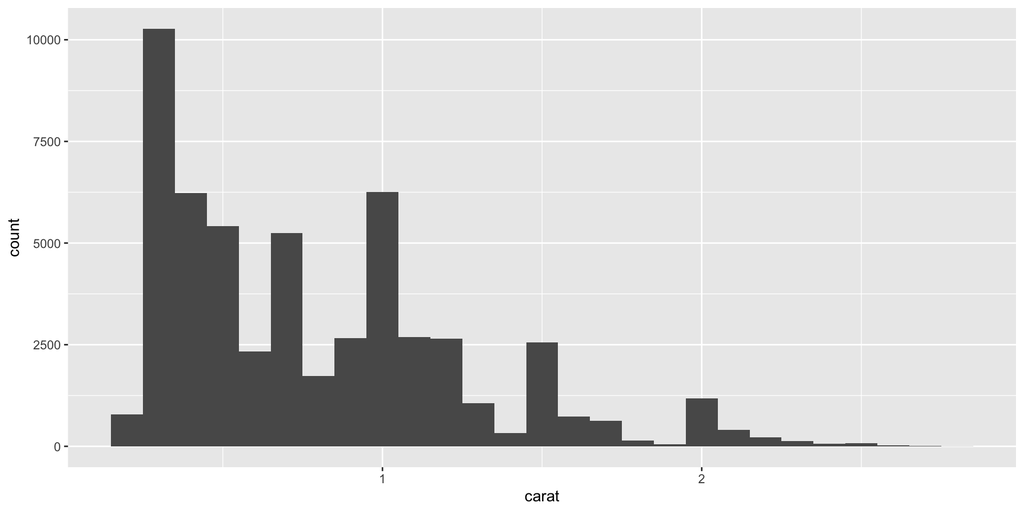

```r
smaller <- diamonds %>%
  filter(carat < 3)

ggplot(data = smaller, mapping = aes(x = carat)) +
  geom_histogram(binwidth = 0.1)
```

## Visualizing Distributions

- Multiple Histograms
- `geom_freqpoly()`performs the same calculation as `geom_histogram()`, but instead of displaying the counts with bars, uses lines instead

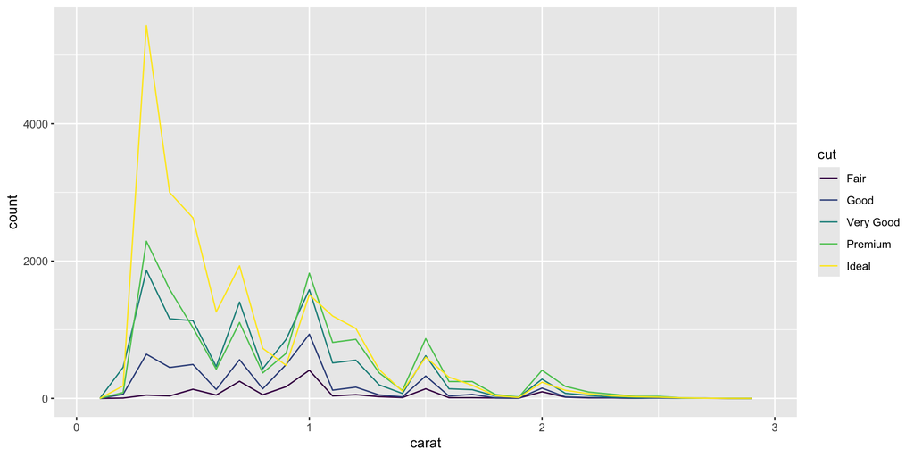

```r
ggplot(data = smaller, mapping = aes(x = carat, colour = cut)) +
  geom_freqpoly(binwidth = 0.1)
```

## Outliers

- Outliers are observations that are unusual; data points that don’t seem to fit the pattern
- Sometimes outliers are data entry errors; other times outliers suggest important new science
- When you have a lot of data, outliers are sometimes difficult to see

## Outliers

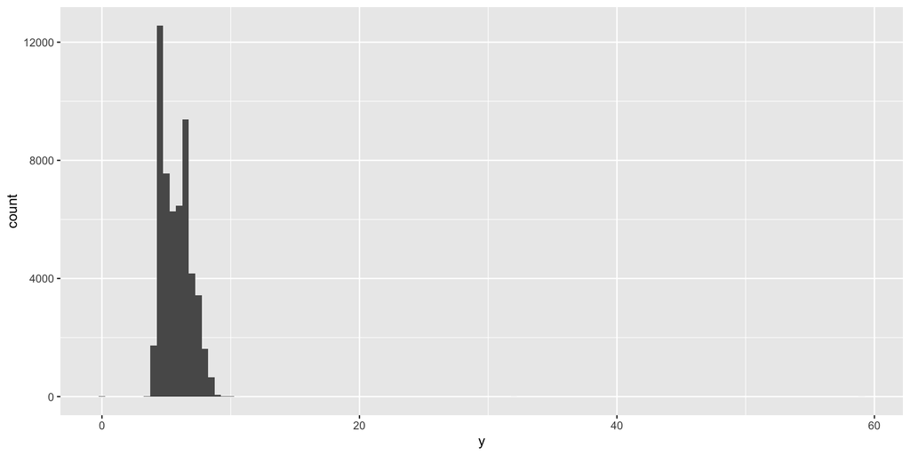

```r
ggplot(diamonds) +
  geom_histogram(mapping = aes(x = y), binwidth = 0.5)
```

- There are so many observations in the common bins that the rare bins are so short that you can’t see them

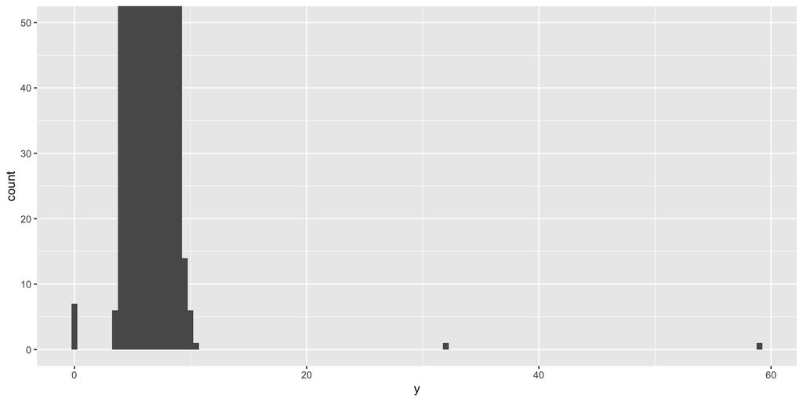

```r
ggplot(diamonds) +
  geom_histogram(mapping = aes(x = y), binwidth = 0.5) +
  coord_cartesian(ylim = c(0, 50))
```

## Outliers

```r
unusual <- diamonds %>%
  filter(y < 3 | y > 20) %>%
  select(price, x, y, z) %>%
  arrange(y)

unusual
```

```
# A tibble: 9 × 4
  price     x     y     z
  <int> <dbl> <dbl> <dbl>
1  5139  0      0    0
2  6381  0      0    0
3 12800  0      0    0
4 15686  0      0    0
5 18034  0      0    0
6  2130  0      0    0
7  2130  0      0    0
8  2075  5.15  31.8  5.12
9 12210  8.09  58.9  8.06
```

- The y variable measures one of the three dimensions of these diamonds in mm
  - Diamonds can’t have a width of 0mm
- Measurements of 32mm and 59mm are implausible
  - Those diamonds are over an inch long, but don’t cost hundreds of thousands of dollars

## Missing Values

- If you have missing values, you have two options:
- Listwise delete
  - Drop the entire row with the strange values

```r
diamonds2 <- diamonds %>%
  filter(between(y, 3, 20))

diamonds2
```

```
# A tibble: 53,931 × 10
   carat cut       color clarity depth table price     x     y     z
   <dbl> <ord>     <ord> <ord>   <dbl> <dbl> <int> <dbl> <dbl> <dbl>
 1  0.23 Ideal     E     SI2      61.5    55   326  3.95  3.98  2.43
 2  0.21 Premium   E     SI1      59.8    61   326  3.89  3.84  2.31
 3  0.23 Good      E     VS1      56.9    65   327  4.05  4.07  2.31
 4  0.29 Premium   I     VS2      62.4    58   334  4.2   4.23  2.63
 5  0.31 Good      J     SI2      63.3    58   335  4.34  4.35  2.75
 6  0.24 Very Good J     VVS2     62.8    57   336  3.94  3.96  2.48
 7  0.24 Very Good I     VVS1     62.3    57   336  3.95  3.98  2.47
 8  0.26 Very Good H     SI1      61.9    55   337  4.07  4.11  2.53
 9  0.22 Fair      E     VS2      65.1    61   337  3.87  3.78  2.49
10  0.23 Very Good H     VS1      59.4    61   338  4     4.05  2.39
# ℹ 53,921 more rows
```

## Missing Values

- Replace the unusual values with `NA`
- Utilize the `ifelse()` command

```r
diamonds2 <- diamonds %>%
  mutate(y = ifelse(y < 3 | y > 20, NA, y))

diamonds2
```

```
# A tibble: 53,940 × 10
   carat cut       color clarity depth table price     x     y     z
   <dbl> <ord>     <ord> <ord>   <dbl> <dbl> <int> <dbl> <dbl> <dbl>
 1  0.23 Ideal     E     SI2      61.5    55   326  3.95  3.98  2.43
 2  0.21 Premium   E     SI1      59.8    61   326  3.89  3.84  2.31
 3  0.23 Good      E     VS1      56.9    65   327  4.05  4.07  2.31
 4  0.29 Premium   I     VS2      62.4    58   334  4.2   4.23  2.63
 5  0.31 Good      J     SI2      63.3    58   335  4.34  4.35  2.75
 6  0.24 Very Good J     VVS2     62.8    57   336  3.94  3.96  2.48
 7  0.24 Very Good I     VVS1     62.3    57   336  3.95  3.98  2.47
 8  0.26 Very Good H     SI1      61.9    55   337  4.07  4.11  2.53
 9  0.22 Fair      E     VS2      65.1    61   337  3.87  3.78  2.49
10  0.23 Very Good H     VS1      59.4    61   338  4     4.05  2.39
# ℹ 53,930 more rows
```

## Conditional Statements

- Additionally, when you want to create a new variable that relies on a complex combination of existing variables
  - Utilize the `ifelse()` or `case_when()` command

```r
diamonds %>%
  mutate(size_category = case_when(
    carat < 0.25 ~ "tiny",
    carat < 0.5  ~ "small",
    carat < 1    ~ "medium",
    carat < 1.5  ~ "large",
    TRUE         ~ "huge"
  )) %>%
  select(size_category, everything())
```

```
# A tibble: 53,940 × 11
   size_category carat cut     color clarity depth table price     x     y     z
   <chr>         <dbl> <ord>   <ord> <ord>   <dbl> <dbl> <int> <dbl> <dbl> <dbl>
 1 tiny           0.23 Ideal   E     SI2      61.5    55   326  3.95  3.98  2.43
 2 tiny           0.21 Premium E     SI1      59.8    61   326  3.89  3.84  2.31
 3 tiny           0.23 Good    E     VS1      56.9    65   327  4.05  4.07  2.31
 4 small          0.29 Premium I     VS2      62.4    58   334  4.2   4.23  2.63
 5 small          0.31 Good    J     SI2      63.3    58   335  4.34  4.35  2.75
 6 tiny           0.24 Very G… J     VVS2     62.8    57   336  3.94  3.96  2.48
 7 tiny           0.24 Very G… I     VVS1     62.3    57   336  3.95  3.98  2.47
 8 small          0.26 Very G… H     SI1      61.9    55   337  4.07  4.11  2.53
 9 tiny           0.22 Fair    E     VS2      65.1    61   337  3.87  3.78  2.49
10 tiny           0.23 Very G… H     VS1      59.4    61   338  4     4.05  2.39
# ℹ 53,930 more rows
```